# Homelessness Midpoint Deliverable

Gabby, Vincent, and Eric

11/17/2019

## Topic

Our domain of interest is Homelessness. In the Seattle King County area, there are about 12,500 homeless people living on the streets or in shelters. This not only makes the living environment of Seattle worse but also impacts the citizens’ daily life(crime, policing, junk/RVs, harassment etc). Confronted with this in our daily lives, we are interested in better understanding the issue locally and nationally including some of the factors contributing to it.

## Summary

In 2016 there were 548502 in the US, with an average of 10548 in each State. Wyoming had the fewest homeless and California the most. There were a total of 39418 homeless veterans, 3823 homeless under 18 years old, and 193825 homeless with families.

## Table

Summary Table

| State | Avg.CPI | Homeless Population | Total Population | Percentage(%) |
| --- | --- | --- | --- | --- |
| NY | 69.65 | 75131 | 19745289 | 0.38 |
| HI | 82.89 | 4940 | 1428557 | 0.35 |
| NV | 51.28 | 7197 | 2940058 | 0.24 |
| CA | 71.16 | 77803 | 39250017 | 0.20 |
| WA | 58.64 | 14161 | 7288000 | 0.19 |
| AK | 71.17 | 1105 | 741894 | 0.15 |
| AZ | 47.48 | 7467 | 6931071 | 0.11 |
| MA | 79.62 | 6240 | 6811779 | 0.09 |
| TN | 53.50 | 5309 | 6651194 | 0.08 |
| MN | 59.04 | 4402 | 5519952 | 0.08 |

This summary table provides aggregate information of 10 states with the highest percentages of Homeless population. It also comes with the average CPI(Cosumer Price Index), total populaion of each state. We include this table to show you which states are most impacted by Homeless problem.

## Shelter Analysis

The visualization below illustrates the proportion of Sheltered Homeless to Unsheltered Homeless individuals, in each State in 2016. To make variance even more apparent, the pie charts gets larger when there is a high proportion of Unsheltered Homeless.

You can see that states with more moderate climates, such as California and Florida have greater portions of unsheltered homeless.

[interactive chart not shown]

## CPI Analysis

The following is a preview. As you can see in the scatter plot, there is a potential correaltion between CPI and Homeless rate. However, it is not quite obvious. To visualize the potential correlation between higher cost of living and Homeless rate, we have included another chart for better comparison.

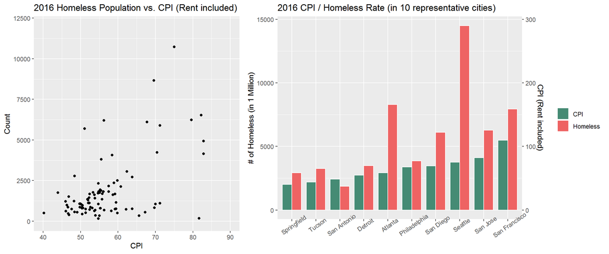

This bar chart includes 10 representative cities ranging from cities with below average CPIs to those with the higest CPIs. As you can tell, as the CPI goes up, the Homelessness rates goes up. We have calculated the number of Homeless people in 1 Million people to eliminate the influence by city population(larger cities tend to have higher CPIs and higher population, which means more homeless people). Note that Atlanta and Seattle are two outlier in this comparison, with unusual high population of Homeless. However, this can’t deny that Homeless rate is correlated with CPI. We should be cocerned that Seattle’s high homeless population has something to do with other factors such as lack of governance and bad drug control, etc.

## Chart 3 Observations